# Robust PCA for functional snippets

Hyunsung Kim

2021-05-13

# Noise variance

- 코드에서 실수가 있었음 (average에서는 성립하지만, median에서는 성립하지 않음)

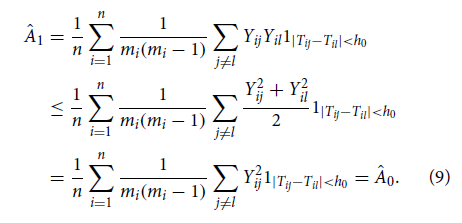

- Estiamte이 크게 달라짐
  - 0.1 => 0.7
  - 0.03 => 0.5
- trimmed mean으로 사용하면 값이 줄어들긴 하지만 어느정도를 trim할지를 결정해야함

# AMI clustering

- 0이 많은 case를 강제로 추가하여 outlier로 생각하고 clustering
- 나머지 setting은 기존과 동일
- 결과는 좋지 않음… (0이 많은 case들이 전체적으로 값이 작은 curve들과 같은 그룹으로 묶임)

# M-estimator for partially observed functional data

## Marginal M-estimator for mean

> Park, Y., Chen, X., & Simpson, D. G. (2020). Robust M-estimation for Partially Observed Functional Data. arXiv preprint arXiv:2002.08560.

$$\hat{\mu}^M(t) = \arg\min_{\theta} \sum_{i=1}^n O_i(t) \rho\left( X_i(t) - \theta \right)$$

## Marginal M-estimator for covariance

- Kraus (2015)에서의 covariance 식을 M-estimator로 바꿔본 형태 (`MASS::huber()`)

$$\hat{\sigma}^M(s,t) = \arg\min_{\theta} \sum_{i=1}^n U_i(s,t) \rho\left( \{X_i(s) - \hat{\mu}_{st}^M(s)\} \{X_i(t) - \hat{\mu}_{st}^M(t)\} - \theta \right),$$
where $U_i(s,t) = O_i(s)O_i(t)$, and
$$\hat{\mu}_{st}^M(t) = \arg\min_{\theta} \sum_{i=1}^n U_i(s, t) \rho\left( X_i(t) - \theta \right).$$

# Simulation

## Settings

- **Completion**
  - Delaigle et al. (2020) setting
  - 20% outlier + partially observed
  - 5 FPC scores
  - 50 repetitions
- **Clustering**
  - shifted Doppler signal setting
    - 4개 true clusters
    - 512 => 128 timepoints로 줄여서 확인
  - 20% outliers + partially observed
  - Huber의 경우, variance가 0이 되는 양끝 부분은 가장 가까운 값으로 대체
  - 2 FPC scores
  - Trimmed $k$-means clustering 적용 (outlier 비율만큼 trim되도록 설정)
  - 50 repetitions
- **비교 방법론**
  - **Yao (2005)** : PCA (CE)
  - **Huber** : Lin & Wang (2020) + Huber loss function + PCA (CE)
  - **M-est** : Marginal M-estimator for mean and covariances + PCA (CE)
  - **M-est (smooth)** : M-est + 2D smoothed covariance + PCA (CE)
  - **Kraus (2015)** : PCA (Kraus)
  - **Kraus-M** : M-est + PCA (Kraus)
  - **Kraus-M (smooth)** : M-est (smooth) + PCA (Kraus)
- **Pre-smoothing**
  - Kraus (2015)는 penalized smoothing spline을 통해 noise를 제거해준 후에 PCA를 적용. (따라서 따로 noise variance를 추정하지 않음.)
  - `pspline::sm.spline()`을 사용하여 penalized smoothing spline 적용한 경우의 결과도 요약.

## Completion result

Table 1. Average MISE, MSE, and its standard errors of completion for simulated data from 50 repetitions.

| Method | Pre-smoothing X MISE | Pre-smoothing X MSE | Pre-smoothing MISE | Pre-smoothing MSE |
| --- | --- | --- | --- | --- |
| Yao (2005) | 0.86 (4.1) | 3.93 (14.09) | 727.62 (5101.09) | 5248.77 (36701.18) |
| Huber | 0.06 (0.03) | 0.36 (0.18) | 0.05 (0.03) | 0.30 (0.18) |
| M-est | 0.37 (1.78) | 1.67 (7.79) | 0.07 (0.07) | 0.33 (0.30) |
| M-est (smooth) | 0.08 (0.11) | 0.36 (0.50) | 0.27 (0.63) | 0.99 (1.96) |
| Kraus (2015) | 0.37 (0.08) | 2.73 (0.63) | 0.15 (0.09) | 1.14 (0.67) |
| Kraus-M | 0.16 (0.05) | 1.45 (0.45) | 0.06 (0.03) | 0.50 (0.26) |
| Kraus-M (smooth) | 0.06 (0.02) | 0.49 (0.27) | 0.11 (0.05) | 1.01 (0.38) |

Table 2. Average MISE, MSE, and its standard errors of reconstruction for simulated data from 50 repetitions.

| Method | Pre-smoothing X MISE | Pre-smoothing X MSE | Pre-smoothing MISE | Pre-smoothing MSE |
| --- | --- | --- | --- | --- |
| Yao (2005) | 2.34 (7.86) | 2.41 (8.11) | 1030.08 (7151.56) | 1088.87 (7569.14) |
| Huber | 0.07 (0.03) | 0.08 (0.04) | 0.06 (0.04) | 0.07 (0.05) |
| M-est | 0.45 (1.86) | 0.49 (2.04) | 0.09 (0.08) | 0.1 (0.08) |
| M-est (smooth) | 0.09 (0.12) | 0.10 (0.13) | 0.29 (0.64) | 0.31 (0.69) |

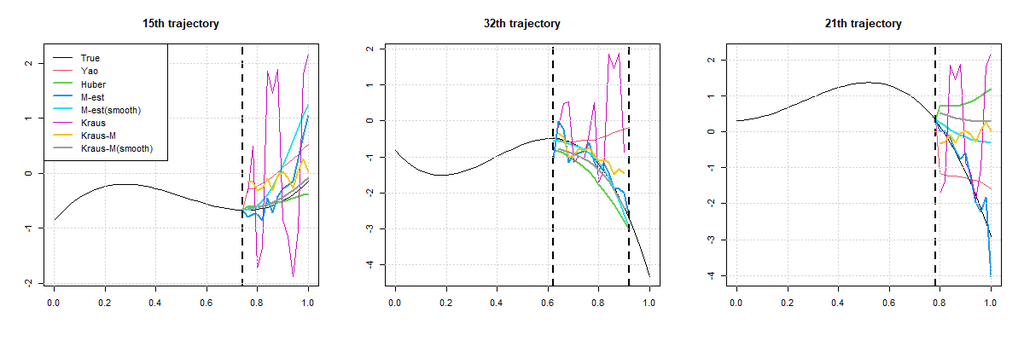

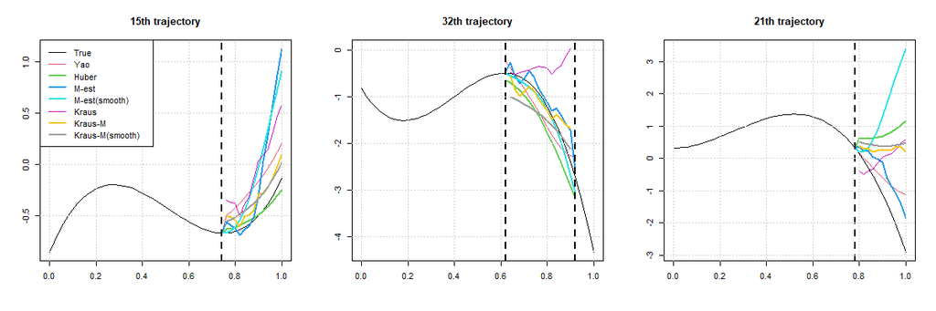

Figure 1. Completion for missing parts of 1st simulated data. Top is obtained from raw data, and bottom from pre-smoothed data.

## Clustering result

Table 3. Average CCR (Correct classification rate), average aRand (Adjusted Rand index), and its standard errors from Trimmed $k$-means clustering using 2 FPCs from 50 repetitions.

| Method | Pre-smoothing X CCR | Pre-smoothing X aRand | Pre-smoothing CCR | Pre-smoothing aRand |
| --- | --- | --- | --- | --- |
| Yao (2005) | 0.64 (0.11) | 0.38 (0.15) | 0.61 (0.11) | 0.36 (0.14) |
| Huber | 0.52 (0.06) | 0.24 (0.08) | 0.69 (0.04) | 0.45 (0.06) |
| M-est | 0.95 (0.02) | 0.89 (0.06) | 0.79 (0.04) | 0.58 (0.06) |
| M-est (smooth) | 0.64 (0.04) | 0.41 (0.07) | 0.63 (0.05) | 0.40 (0.07) |
| Kraus (2015) | 0.61 (0.12) | 0.35 (0.14) | 0.76 (0.08) | 0.57 (0.11) |
| Kraus-M | 0.97 (0.02) | 0.92 (0.05) | 0.83 (0.06) | 0.65 (0.08) |
| Kraus-M (smooth) | 0.79 (0.03) | 0.65 (0.05) | 0.77 (0.04) | 0.61 (0.07) |

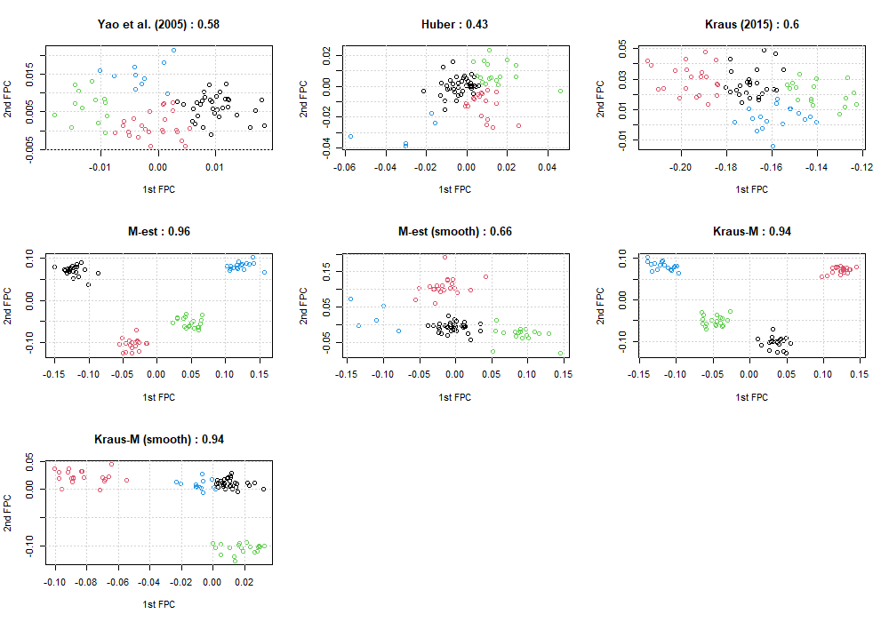

Figure 2. Scatter plot between 1st and 2nd FPC scores, and its CCR from 1st simulated data. Each cluster is assigned by the trimmed $k$-means clustering algorithm, and trimmed points are excluded from the plot.

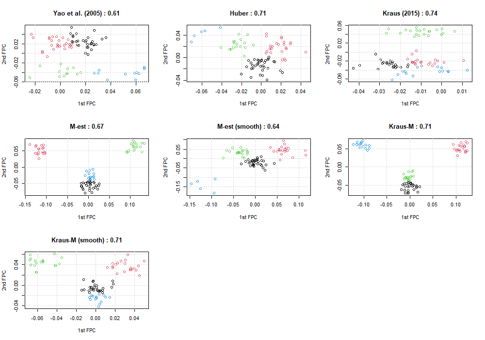

Figure 3. Scatter plot between 1st and 2nd FPC scores, and its CCR from 1st simulated data after pre-smoothing is performed. Each cluster is assigned by the trimmed $k$-means clustering algorithm, and trimmed points are excluded from the plot.